# MetaboDynamics

Here we want to show a complete workflow to analyze concentration tables. As example we have a data set of irradiated cancer cells lines that were observed over four timepoints. This package was built to faciliate the analysis of longitudinal metabolomics data. Common tools mostly only allow the comparison between two timepoints or experimental conditions and are using frequentist statistical methods. As metabolomics data is often noise robust methods for the estimation of dynamics are needed. We employ a hierachical Bayesian model for that.

## setup: load required packages

```r
library(MetaboDynamics)
library(ggplot2)
library(dplyr)
library(tidyr)
```

## load data and plot data overview

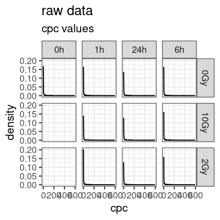

```r
data("intra")
ggplot(intra, aes(x = cpc)) +
  geom_density() +
  theme_bw() +
  facet_grid(cols = vars(time), rows = vars(dose)) +
  ggtitle("raw data", "cpc values")
```

We can see that there are only measurements at 0h for the 0Gy dose. As this is the control before irradiation the 0h measurement also is valid for the 2Gy and 10Gy group. Furthermore we can see that the cpc values are not distributed normally. So let’s assign the 0h values also to 2Gy and 10 Gy and log-transform.

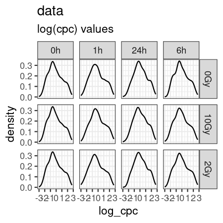

```r
# we are taking t=0h for every radiation dose
# we will duplicate the measurements for 0h for 2Gy and 10Gy
temp <- intra[intra$time == "0h", ]
temp$dose <- "2Gy"
temp2 <- temp
temp2$dose <- "10Gy"
intra <- rbind(intra, temp, temp2)
rm(temp, temp2)
intra <- intra %>% mutate(log_cpc = log10(cpc))

# we standardize to a mean of zero and a standard deviation of one of log-transformed data
ggplot(intra, aes(x = log_cpc)) +
  geom_density() +
  theme_bw() +
  facet_grid(cols = vars(time), rows = vars(dose)) +
  ggtitle("data", "log(cpc) values")
```

That looks better. As we want to estimate the dynamics of every single metabolite next let’s think about what that means. We want to estimate the deviations at every single time point from the metabolites mean over time.

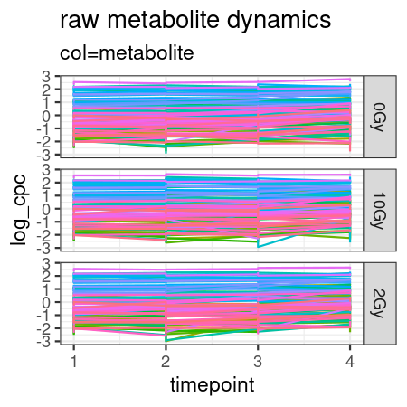

```r
# get time as numeric variable
intra$time <- gsub("h", "", intra$time)
intra$time <- as.numeric(intra$time)
intra <- intra %>% arrange(as.numeric(time))
ggplot(intra) +
  geom_line(aes(x = as.numeric(as.factor(time)), y = log_cpc, col = metabolite)) +
  theme_bw() +
  xlab("timepoint") +
  theme(legend.position = "none") +
  facet_grid(rows = vars(dose)) +
  ggtitle("raw metabolite dynamics", "col=metabolite")
```

As the concentrations of metabolites can differ by magnitudes from each other, we standardize each metabolite at each radiation dose to a mean of zero and a standard deviation of one.

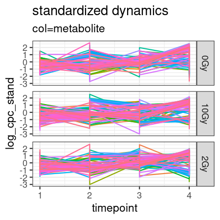

```r
intra <- intra %>%
  group_by(dose, metabolite) %>%
  mutate(log_cpc_stand = ((log_cpc - mean(log_cpc)) / sd(log_cpc)))
ggplot(intra) +
  geom_line(aes(
    x = as.numeric(as.factor(time)),
    y = log_cpc_stand, col = metabolite
  )) +
  theme_bw() +
  xlab("timepoint") +
  theme(legend.position = "none") +
  facet_grid(rows = vars(dose)) +
  ggtitle("standardized dynamics", "col=metabolite")
```

Now we can finally model the dynamics. We have done the modeling beforehand, so that it does not take to much time during this Vignette.

## Model dynamics

```r
# fit model
fits_dynamics <- fit_dynamics_model(
  data = intra, cpc = "log_cpc_stand",
  condition = "dose", max_treedepth = 14,
  adapt_delta = 0.999, iter = 4000, cores = 7
)
```

```
#> 0Gy2Gy10Gy
```

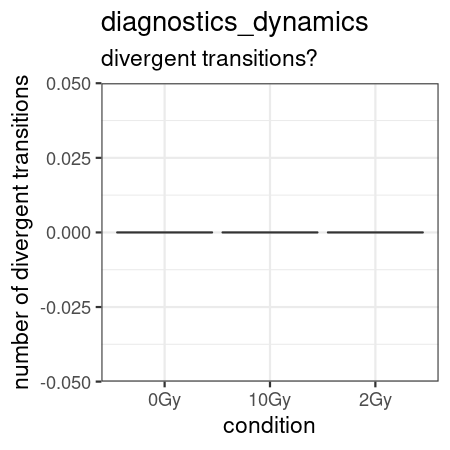

```r
# load("/media/home/fits_dynamics.RData")
# extract diagnostics
diagnostics_dynamics <- extract_diagnostics_dynamics(
  data = intra, iter = 4000,
  fits = fits_dynamics
)
diagnostics_dynamics[["plot_divergences"]]
```

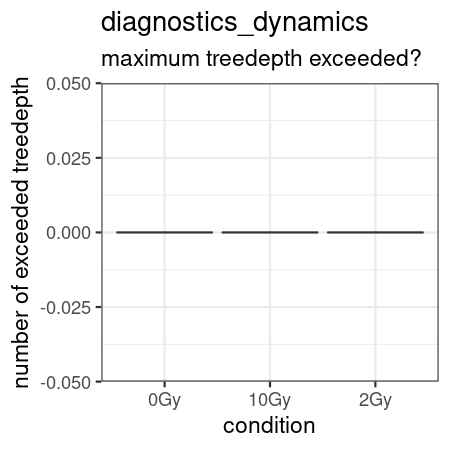

```r
diagnostics_dynamics[["plot_treedepth_error"]]
```

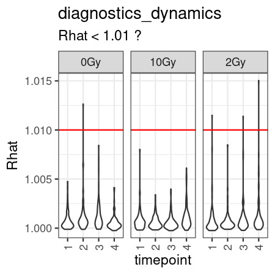

```r
diagnostics_dynamics[["plot_rhat"]]
```

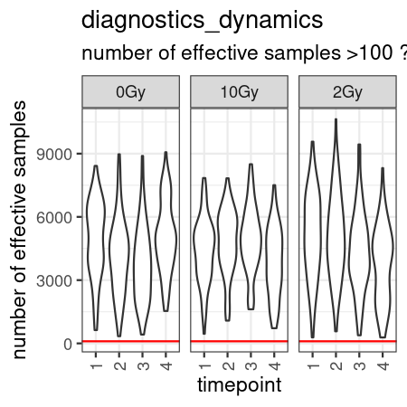

```r
diagnostics_dynamics[["plot_neff"]]
```

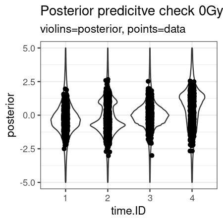

```r
diagnostics_dynamics[["plot_PCC_0Gy"]]
```

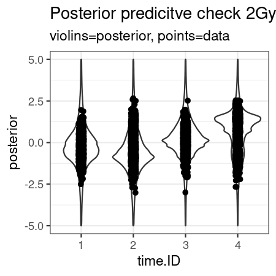

```r
diagnostics_dynamics[["plot_PCC_2Gy"]]
```

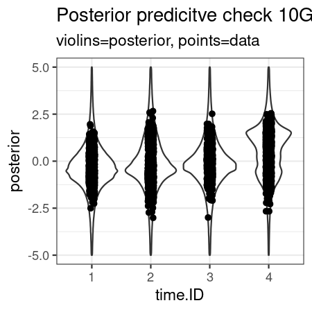

```r
diagnostics_dynamics[["plot_PCC_10Gy"]]
```

For our experimental dataset this might take up to 10 minutes per radiation dose depending on how many cores are used.

This returns a list of model fits that are named by the experimental condition (“0Gy”,“2Gy”,“10Gy”). With extract_diagnostics_dynamics() we can extract all the diagnostic criteria of Bayesian models (rhat,neff,divergences,max_treedept) and visualize them. Additionally dataframes for visual Posterior predictive checks (PPC) are prepared and Plots generated for the PPCs and diagnostic criteria.

After checking the diagnostic criteria and the PPC we can extract the estimates:

```r
# extract estimates
estimates_dynamics <- extract_estimates_dynamics(
  data = intra, fits = fits_dynamics,
  iter = 4000
)
```

We get two major outputs: 1) the estimation of concentration differences between two subsequent timepoints of each metabolite at each experimental condition 2) the dynamic profiles of each metabolites at each experimental condition

## 1) differences between two timepoints

[figure not shown]

```r
# 1) the differences between two timepoints
# set numer of timepoints
estimates_dynamics[["plot_timepoint_differences"]]
```

If the 95% highest density interval of the posterior does not include zero we can confidently stat that there is a difference in mean concentrations between two timepoints. If the 95% HDI is left of zero we have a decrease in concentrations between the two timepoints, if it is right of zero we have an increase in concentrations between timepoints.

## 2) dynamic profiles

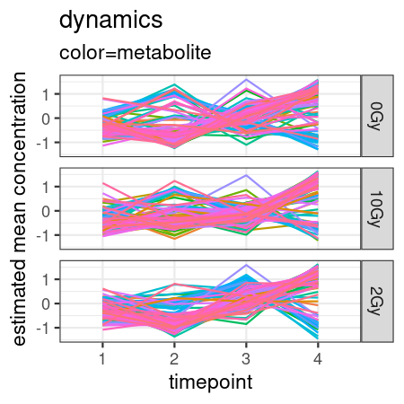

```r
# 2) dynamic profiles
estimates_dynamics[["plot_dynamics"]]
```

So we now have dynamic profiles of the metabolites at each radiation dose. What do we do with this? We could cluster these dynamics vectors, that we obtained (estimates_dynamics[,c(“mu1.mean”:“mut.mean)]) to see if we find groups of metabolites that have similar dynamics.

# cluster dynamics

We combine all clustering results in one dataframe that hold columns “metabolite”, “condition”, “mu1-t.mean” and “cluster”. “Cluster” refers to the cluster ID of the metabolite.

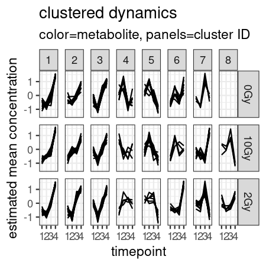

```r
temp <- cluster
temp <- temp %>% pivot_longer(
  cols = c(mu1_mean, mu2_mean, mu3_mean, mu4_mean),
  names_to = "timepoint", values_to = "mu_mean"
)
ggplot(temp, aes(
  x = as.factor(as.numeric(as.factor(timepoint))),
  y = mu_mean, group = metabolite
)) +
  geom_line() +
  xlab("timepoint") +
  ylab("estimated mean concentration") +
  theme_bw() +
  theme(legend.position = "none") +
  facet_grid(rows = vars(condition), cols = vars(cluster)) +
  ggtitle("clustered dynamics", "color=metabolite, panels=cluster ID")
```

```r
rm(temp)
```

# Over-representation analysis of functional modules in dynamic clusters

We now have clusters of metabolites with similar dynamics per radiation dose. To quantify the possible biological function of these dynamic clusters we retrieved from the KEGG-database the following information (with package KEGGREST): 1) to which functional modules our experimental metabolites are annotated and 2) which metabolites are annotated to functional modules in general The functional modules of the KEGG-database are organised in three hierchacies: upper, middle and lower. Here we will do funtional analysis on the middle hierachy. To facilitate analysis the dataframes “metabolite_modules” which holds the information about experimental metabolites and “modules_compounds” which holds the information about which metabolites are in general annotated to functional modules. We load both datasets and can inspect the documentation.

```r
data("metabolite_modules")
help("metabolite_modules")
head(metabolite_modules)
```

```
#> # A tibble: 6 × 8
#>    ...1 metabolite    KEGG  module_id module_name upper_hierachy middle_hierachy
#>   <dbl> <chr>         <chr> <chr>     <chr>       <chr>          <chr>
#> 1     1 1-Aminocyclo… C012… M00368    Ethylene b… Pathway modul… Amino acid met…
#> 2     2 2-Aminomucon… C022… M00038    Tryptophan… Pathway modul… Amino acid met…
#> 3     3 2-Phosphogly… C006… M00001    Glycolysis… Pathway modul… Carbohydrate m…
#> 4     4 2-Phosphogly… C006… M00002    Glycolysis… Pathway modul… Carbohydrate m…
#> 5     5 2-Phosphogly… C006… M00003    Gluconeoge… Pathway modul… Carbohydrate m…
#> 6     6 2-Phosphogly… C006… M00346    Formaldehy… Pathway modul… Energy metabol…
#> # ℹ 1 more variable: lower_hierachy <chr>
```

```r
data("modules_compounds")
help("modules_compounds")
head(modules_compounds)
```

```
#> # A tibble: 6 × 6
#>    ...1 module_id kegg_id upper_hierachy  middle_hierachy         lower_hierachy
#>   <dbl> <chr>     <chr>   <chr>           <chr>                   <chr>
#> 1     2 M00001    C00267  Pathway modules Carbohydrate metabolism Central carbo…
#> 2     3 M00001    C00668  Pathway modules Carbohydrate metabolism Central carbo…
#> 3     4 M00001    C05345  Pathway modules Carbohydrate metabolism Central carbo…
#> 4     5 M00001    C05378  Pathway modules Carbohydrate metabolism Central carbo…
#> 5     6 M00001    C00111  Pathway modules Carbohydrate metabolism Central carbo…
#> 6     7 M00001    C00118  Pathway modules Carbohydrate metabolism Central carbo…
```

For the functional analysis we employ a hypergeometric model:

```r
ORA <- ORA_hypergeometric(background = modules_compounds, annotations = metabolite_modules, clusters = cluster, tested_column = "middle_hierachy")
```

[output not shown]

[figure not shown]

```r
ORA[["plot_ORA"]]
```

```r
ORA <- ORA_hypergeometric(background = modules_compounds, annotations = metabolite_modules, clusters = cluster[cluster$condition == "0Gy", ], tested_column = "lower_hierachy")
```

[figure not shown]

```r
ORA[["plot_ORA"]]
```

Great, we can now see which functional module is over- or under-represented in which dynamic cluster!

# Comparison of clusters of different experimental conditions

## dynamics

We can not only do over-representation analysis of KEGG-functional modules but also compare dynamic clusters across different experimental conditions.

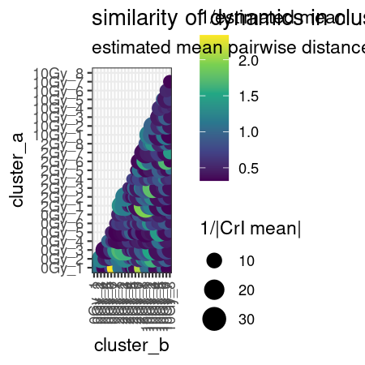

```r
comparison_dynamics <- compare_dynamics(clusters = cluster, dynamics = c("mu1_mean", "mu2_mean", "mu3_mean", "mu4_mean"))
comparison_dynamics[["plot_dynamic_comparison"]]
```

The bigger and brighter a point is the smaller is the mean distance between dynamic clusters and the smaller is the standard deviation. That means big bright moins indicate high dynamic similarity which small spread. Here 10Gy_7 and 2Gy_8 have high similiarity in dynamics. If we recall the ORA analysis this pair also 2Gy_8 has less over-expression of Carbohydrate metabolism.

## metabolites

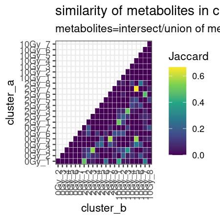

```r
comparison_metabolites <- compare_metabolites(clusters=cluster)
comparison_metabolites[["plot_metabolite_comparison"]]
```

Can we facilitate visualization?

## combine both

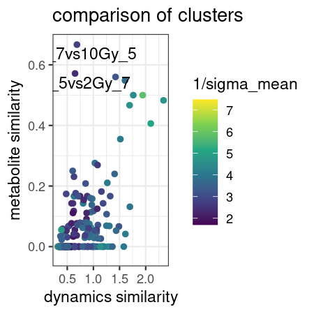

```r
dynamics <- comparison_dynamics[["estimates"]]
metabolites <- comparison_metabolites[["Jaccard"]]
temp <- left_join(dynamics,metabolites,by=c("cluster_a","cluster_b"))
ggplot(temp,aes(x=1/mu_mean,y=Jaccard))+
  geom_point(aes(col=1/sigma_mean))+
  theme_bw()+
  geom_text(aes(label=ifelse(Jaccard>0.4&1/mu_mean<1.0,comparison,NA)),nudge_y=-0.03)+
  scale_color_viridis_c()+
  xlab("dynamics similarity")+
  ylab("metabolite similarity")+
  ggtitle("comparison of clusters")
```

We can find two cluster pairs that are pretty similar in regards to their composing metabolites but dissimilar in regards to their dynamics. Their ORA profiles are quit similar as expected from the similar metabolite compositions.